# HW 11 Stat 139

Callin Switzer

November 25, 2014

# #1a

$\hat{\sigma}^2$ = Residual SS / d.f.

$\hat{\sigma}$ is the “Residual standard error” from the lm() function

Adj$R^2$ = 100*((total mean square) - (residual mean square))/total mean square

Cp = p + (n-p)$\frac{\hat{\sigma^2} - \hat{\sigma^2_{full}}}{\hat{\sigma^2_{full}}}$

BIC = n log(SSRes / n) + p log(n)

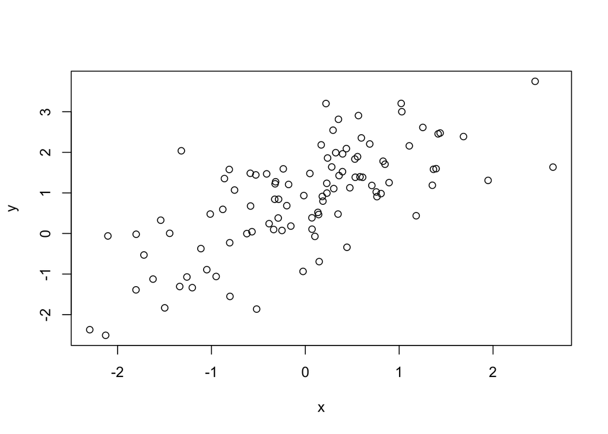

Call: lm(formula = y ~ x)

Residuals: Min 1Q Median 3Q Max -2.27269 -0.56267 -0.00227 0.64581 2.36291

Coefficients: Estimate Std. Error t value Pr(>|t|)  
(Intercept) 0.88461 0.09165 9.652 6.89e-16 *x 0.91557 0.09362 9.780 3.64e-16* — Signif. codes: 0 ‘**’ 0.001 ’**’ 0.01 ’’ 0.05 ‘.’ 0.1 ‘’ 1

Residual standard error: 0.9164 on 98 degrees of freedom Multiple R-squared: 0.4939, Adjusted R-squared: 0.4888 F-statistic: 95.65 on 1 and 98 DF, p-value: 3.636e-16

Call: lm(formula = y ~ 1)

Residuals: Min 1Q Median 3Q Max -3.3834 -0.7826 0.2135 0.7619 2.8752

Coefficients: Estimate Std. Error t value Pr(>|t|)  
(Intercept) 0.8742 0.1282 6.821 7.26e-10 *** — Signif. codes: 0 ‘**’ 0.001 ’**’ 0.01 ’’ 0.05 ‘.’ 0.1 ‘’ 1

Residual standard error: 1.282 on 99 degrees of freedom

[1] 0.916436 [1] 0.4939248 [1] 0.4887608 [1] 0.4887608 [1] 0.0345825